# Homework #1

## Manipulating vectors

Please run the following commands in order to set up the following exercises.

```r
require('ggplot2')
load(url('http://www.stolaf.edu/people/olaf/cs125/hw8.RData'))
```

Note that this loads several objects into your environment: 8 vectors of data and a new function called `draw`. If at some point you want to restore the data, it is fine to paste these commands in again whenever you need them.

Let’s see whether the drawing function is working correctly. Try typing in the following command and see what it does:

[figure not shown]

```r
draw(p0x, p0y)
```

If all goes well, a simple sketch of Calvin should appear. If you print `p0x`, you will see that it is a vector of numbers, and `p0y` is another vector of numbers, both of the same length. `p0x` and `p0y` contain the x and y coordinates, respectively, of the points along the line segments that make up the simple Calvin sketch. As an experiment, try the following:

[figure not shown]

```r
draw(p0x, p0y + 25)
```

Hopefully, the result is that Calvin appeared to move up a distance of 25 units. Before proceeding with the exercises, please think through what is happening with these commands, since it will be easier to answer the following questions if you clearly understand how the two vectors are related to the plot.

1. Let’s take a look at the another drawing:

[figure not shown]

```r
draw(p2x, p2y)
```

here, we almost have four duplicates of Calvin in several places, but the upper right drawing has been shifted to the left. Please move that part of the drawing to the right, so that the four Calvins are symmetrically placed (the same distance apart both horizontally and vertically).

SOLUTION:

The idea here is that we can figure out which values we’ll be modifying by looking at the drawing and deciding a combination of logical operations that would isolate all of those points. Once we have them, we want to add something around 15 to each of their x coordinates. Below we show two fine methods to do so:

[figure not shown]

```r
x <- p2x # create a copy in case we mess anything up!
# method one: change the x's in place
x[p2x > 40 & p2y > 50] <- x[p2x > 40 & p2y > 50] + 15
draw(x, p2y)
```

[figure not shown]

```r
# method two: vector addition
x_add <- rep(0, length(p2x))
x_add[p2x > 40 & p2y > 50] <- 15
draw(p2x + x_add, p2y)
```

3. Let’s take a look at a third example:

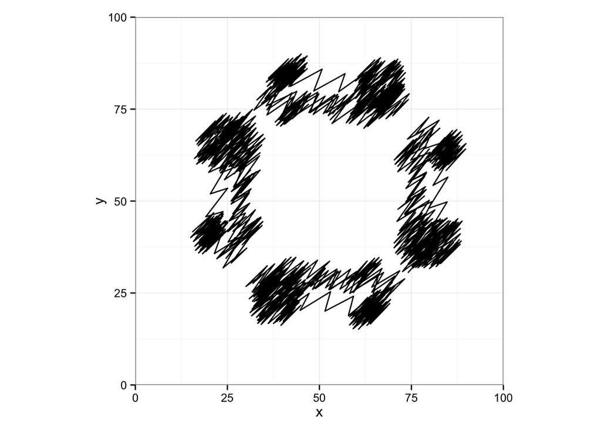

```r
draw(p3x, p3y)
```

here, we almost have four duplicates of Hobbes in several places, but every other point has been moved five units up and to the right, making it almost impossible to see Hobbes anywhere. Please try to resolve the four duplicates of Hobbes.

SOLUTION:

Again we’ll be subsetting and changing our vectors in place, but we’ll be subsetting based on their indices directly instead of by logical conditions.

[figure not shown]

```r
x <- p3x # again, we can make copies just to leave the original data intact
y <- p3y
x[seq(1, length(x), 2)] <- x[seq(1, length(x), 2)] - 5
y[seq(1, length(x), 2)] <- y[seq(1, length(x), 2)] - 5
draw(x, y)
```

## Manipulating dataframes

4. Show the code to create a data frame such that the first column contains the built-in “letters” data set and the second column contains the integers from 1 to 26.

SOLUTION:

```r
data.frame(alphabet = letters, ints = 1:26)
```

For the following exercises, load in the built in earthquake data set.

```r
data(quakes)
```

5. How would you find information about this data frame? How many rows and columns does it have?

   SOLUTION:

```r
?quakes
dim(quakes)
```

```
## [1] 1000    5
```

6. Based purely on the description of the columns (found with `?quakes`), would you expect a relationship between the 4th and 5th columns? Why or why not?

   SOLUTION:

   We would expect there to be a positive relationship between the two: earthquakes that are higher in magnitude will likely be detected by more stations.
7. Show a command you could use to find the average (mean) magnitude of all earthquakes that occurred below the median depth of all earthquakes. Note that earthquakes that are *below* actually have larger depths.

   SOLUTION:

```r
# either subset like a vector
mean(quakes$mag[quakes$depth > median(quakes$depth)])
```

```
## [1] 4.523
```

```r
# or subset like a matrix
mean(quakes[quakes$depth > median(quakes$depth), "mag"])
```

```
## [1] 4.523
```

8. How does the average magnitude of these “deep” earthquakes compare to the magnitude of “shallow” (above median depth) earthquakes?

   SOLUTION:

```r
mean(quakes$mag[quakes$depth < median(quakes$depth)])
```

```
## [1] 4.718
```

The mean magnitude of the shallow quakes is higher than the mean magnitude of the deep quakes (by approx. .2).

9. Show the command you would use to get the row(s) with the smallest value in the `depth` column.

   SOLUTION:

```r
quakes[quakes$depth == min(quakes$depth), ]
```

```
##        lat  long depth mag stations
## 70  -15.46 187.8    40 5.5       91
## 166 -34.20 179.4    40 5.0       37
## 366 -26.78 183.6    40 4.6       22
## 403 -30.40 181.4    40 4.3       17
## 541 -15.90 167.4    40 5.5       86
## 552 -20.33 168.7    40 4.8       38
## 562 -23.92 184.5    40 4.7       17
## 576 -16.49 187.8    40 4.5       18
## 785 -15.00 184.6    40 5.1       54
## 869 -21.14 174.2    40 5.7       78
## 962 -15.78 167.4    40 4.8       42
## 999 -17.40 187.8    40 4.5       14
```

10. Can you think of an interesting plots you would like to create? Please experiment around with plotting.

    SOLUTION:

Here are a couple possibilities:

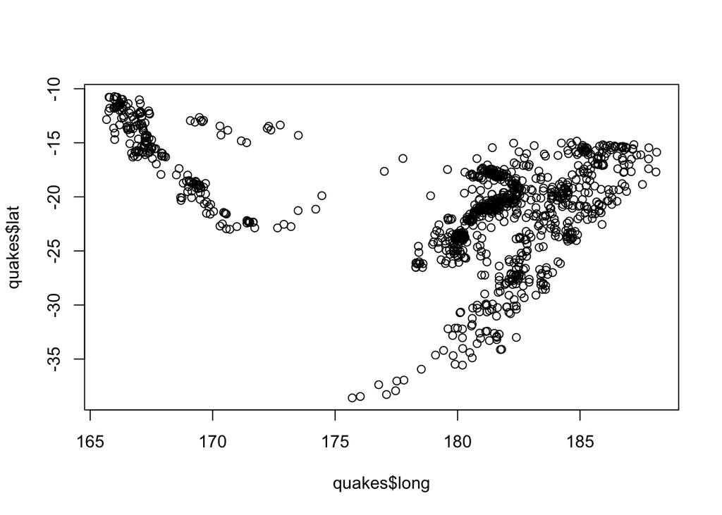

```r
plot(quakes$long, quakes$lat)
```

This is provides a rough map of the quakes in these region near Fiji. We could also investigate the relationship hinted at in question 6.

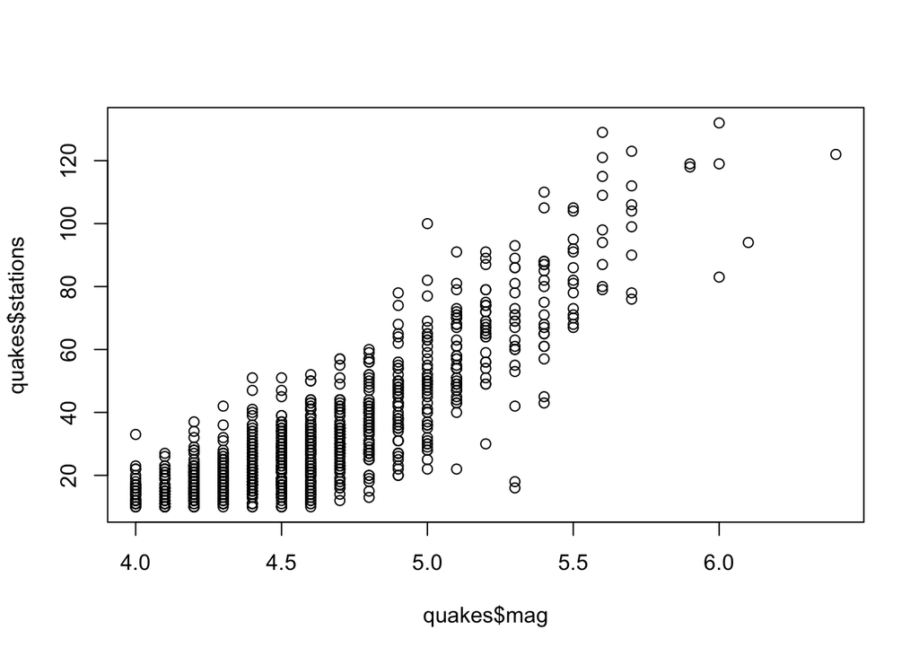

```r
plot(quakes$mag, quakes$stations)
```